# Course Project Practical ML

Barbara Verhaar

12/11/2020

## Synopsis

In this project for the practical ML course (Coursera), the goal was to use data from accelerometers on the belt, forearm, arm, and dumbell of 6 participants. They were asked to perform an unilateral dumbbell biceps curl lifts correctly and incorrectly in 5 different ways with 10 repetitions: A) according to specification, B) throwing elbows to front, C) lifting only halfway, D) lowering only halfway, E) throwing the hips to the front. Read more on this page: http:/groupware.les.inf.puc-rio.br/har#ixzz4TjprBEIK.

In these analyses, I first removed all variables that were not of interest (date, timestamp), and the ones with missing variables. I assessed the predictor variables using dimension reduction with a PCA for every participant separately, since the difference between participants was larger than the difference between classes.

The model had an accuracy of 96.5% (CI 96.0-97.1%), with variables “roll belt”, “pitch forearm”, and “yaw belt”, as top 3 predictors. The table with predictions is presented at the end of this script.

## Libraries used

```r
library(tidyverse)
library(dplyr)
library(caret)
library(Amelia)
library(ggsci)
library(factoextra)
library(aplot)
library(gbm)
```

## Opening test and train datasets

```r
training_url <- "https://d396qusza40orc.cloudfront.net/predmachlearn/pml-training.csv"
test_url <- "https://d396qusza40orc.cloudfront.net/predmachlearn/pml-testing.csv"
training <- read.csv(url(training_url))
testing <- read.csv(url(test_url))
```

## Tidying datasets

The variables such as username, timestamps and time windows are removed from the data sets. The empty fields are being replaced with NA. There are some variables that have almost only NA; those are removed. From the test set only variables that are also present in the training set are kept.

```r
dim(training)
```

```
## [1] 19622   160
```

```r
names(testing)
```

```
##   [1] "X"                        "user_name"                "raw_timestamp_part_1"     "raw_timestamp_part_2"     "cvtd_timestamp"
##   [6] "new_window"               "num_window"               "roll_belt"                "pitch_belt"               "yaw_belt"
##  [11] "total_accel_belt"         "kurtosis_roll_belt"       "kurtosis_picth_belt"      "kurtosis_yaw_belt"        "skewness_roll_belt"
##  [16] "skewness_roll_belt.1"     "skewness_yaw_belt"        "max_roll_belt"            "max_picth_belt"           "max_yaw_belt"
##  [21] "min_roll_belt"            "min_pitch_belt"           "min_yaw_belt"             "amplitude_roll_belt"      "amplitude_pitch_belt"
##  [26] "amplitude_yaw_belt"       "var_total_accel_belt"     "avg_roll_belt"            "stddev_roll_belt"         "var_roll_belt"
##  [31] "avg_pitch_belt"           "stddev_pitch_belt"        "var_pitch_belt"           "avg_yaw_belt"             "stddev_yaw_belt"
##  [36] "var_yaw_belt"             "gyros_belt_x"             "gyros_belt_y"             "gyros_belt_z"             "accel_belt_x"
##  [41] "accel_belt_y"             "accel_belt_z"             "magnet_belt_x"            "magnet_belt_y"            "magnet_belt_z"
##  [46] "roll_arm"                 "pitch_arm"                "yaw_arm"                  "total_accel_arm"          "var_accel_arm"
##  [51] "avg_roll_arm"             "stddev_roll_arm"          "var_roll_arm"             "avg_pitch_arm"            "stddev_pitch_arm"
##  [56] "var_pitch_arm"            "avg_yaw_arm"              "stddev_yaw_arm"           "var_yaw_arm"              "gyros_arm_x"
##  [61] "gyros_arm_y"              "gyros_arm_z"              "accel_arm_x"              "accel_arm_y"              "accel_arm_z"
##  [66] "magnet_arm_x"             "magnet_arm_y"             "magnet_arm_z"             "kurtosis_roll_arm"        "kurtosis_picth_arm"
##  [71] "kurtosis_yaw_arm"         "skewness_roll_arm"        "skewness_pitch_arm"       "skewness_yaw_arm"         "max_roll_arm"
```

[output cut: 17 more lines]

```r
training$X[1:10]
```

```
##  [1]  1  2  3  4  5  6  7  8  9 10
```

```r
training$classe[1:10]
```

```
##  [1] "A" "A" "A" "A" "A" "A" "A" "A" "A" "A"
```

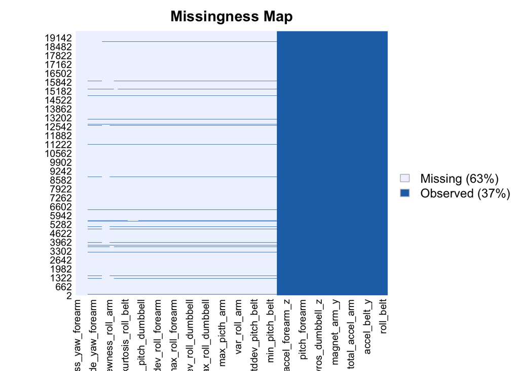

```r
train <- training %>%
    select(-c(3:7)) %>%
    mutate(classe = as.factor(as.character(classe))) %>%
    mutate(user_name = as.factor(as.character(user_name))) %>%
    mutate_if(is.character, list(~na_if(., ""))) %>%
    mutate_if(is.character, list(~na_if(., "#DIV/0!"))) %>%
    mutate_if(is.character, as.numeric) %>%
    mutate_if(is.integer, as.numeric)
missmap(train)
```

```r
train <- train[,which(colSums(is.na(train))==0)]
dim(train)
```

```
## [1] 19622    55
```

```r
any(is.na(train)) ## FALSE
```

```
## [1] FALSE
```

```r
test <- testing %>%
    select(-c(2:7)) %>%
    mutate_if(is.character, list(~na_if(., ""))) %>%
    mutate_if(is.character, list(~na_if(., "#DIV/0!"))) %>%
    mutate_if(is.character, as.numeric) %>%
    mutate_if(is.integer, as.numeric)
test <- test[,which(colSums(is.na(test))==0)]
dim(test)
```

```
## [1] 20 54
```

## Exploratory analyses

### PCA predictors

I made separate PCA plots for each user, since the differences between users seemed to be larger than the differences between classes. The class E movements (purple) seem to be most different from the other groups, but in the other groups there is also quite a lot of overlap.

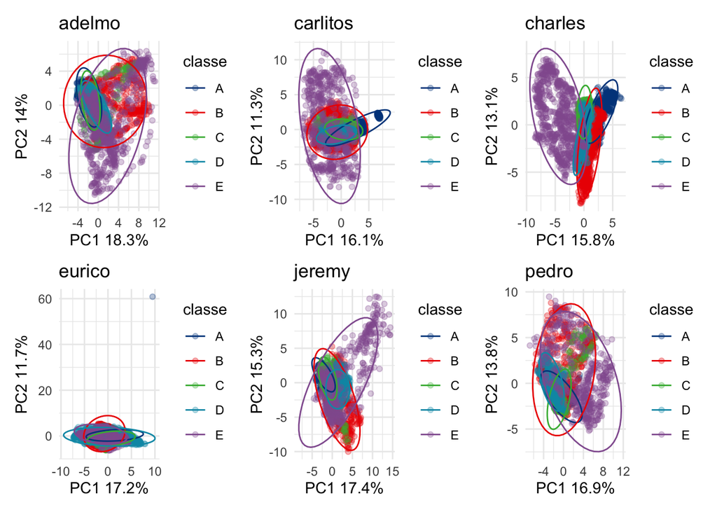

```r
x <- 1
l <- list()
for(i in levels(train$user_name)){
      df <- train %>% filter(user_name==i)
      mat <- df %>% select(-c(1,2,55))
      index <- apply(mat, 2, function(x) ifelse(sd(x)==0, 1, 0))
      mat <- mat[,which(index!=1)]
      rownames(mat) <- df$X
      mat <- as.matrix(mat)

      set.seed(4321)
      res.pca <- prcomp(mat, scale = TRUE)
      sum <- summary(res.pca)
      sum
      pca.data <- as.data.frame(res.pca$x[, 1:2])
      pca.data$classe <- df$classe[match(rownames(pca.data), df$X)]
      pca.data

      pl <- ggplot(pca.data, aes(x=PC1, y=PC2, color=classe)) +
        geom_point(alpha = 0.3)+
        scale_color_lancet() +
        theme_minimal() +
        stat_ellipse() +
        labs(x=str_c('PC1 ', round(sum$importance[2,1]*100, 1), '%'),
             y=str_c('PC2 ', round(sum$importance[2,2]*100,1), '%'),
              title=i)
      l[[x]] <- pl
      x <- x+1
}

plot_list(l)
```

## Model training

```r
rownames(train) <- train$X
train <- train %>% select(-X, -user_name)
nearZero <- nearZeroVar(train, saveMetrics = TRUE)
train <- train %>% select_if(nearZero$percentUnique>1|colnames(.)=="classe")

set.seed(4321)
inTrain <- createDataPartition(train$classe, p = 0.75, list = FALSE)
train2 <- train[inTrain,]
crossVal <- train[-inTrain,]

## model
set.seed(1234)
fit <- train(classe ~ ., method="gbm", data=train,
             preProcess=c("center", "scale"))
pred <- predict(fit, crossVal, type = "raw")
```

## Confusion matrix

A confusion matrix is made from the predicted values versus the actual classes. The accuracy of the model on this set is 96.55%. The most misclassification takes place in class B, throwing elbows to front, with a misclassification rate of 5.9%.

```r
matrix <- confusionMatrix(pred, crossVal$classe)
matrix
```

```
## Confusion Matrix and Statistics
##
##           Reference
## Prediction    A    B    C    D    E
##          A 1379   25    0    0    0
##          B   12  893   23    1   11
##          C    4   28  821   28   11
##          D    0    3    7  774   11
##          E    0    0    4    1  868
##
## Overall Statistics
##
##                Accuracy : 0.9655
##                  95% CI : (0.96, 0.9705)
##     No Information Rate : 0.2845
##     P-Value [Acc > NIR] : < 2.2e-16
##
##                   Kappa : 0.9564
##
##  Mcnemar's Test P-Value : NA
##
## Statistics by Class:
##
##                      Class: A Class: B Class: C Class: D Class: E
## Sensitivity            0.9885   0.9410   0.9602   0.9627   0.9634
## Specificity            0.9929   0.9881   0.9825   0.9949   0.9988
## Pos Pred Value         0.9822   0.9500   0.9204   0.9736   0.9943
## Neg Pred Value         0.9954   0.9859   0.9915   0.9927   0.9918
## Prevalence             0.2845   0.1935   0.1743   0.1639   0.1837
## Detection Rate         0.2812   0.1821   0.1674   0.1578   0.1770
## Detection Prevalence   0.2863   0.1917   0.1819   0.1621   0.1780
## Balanced Accuracy      0.9907   0.9646   0.9713   0.9788   0.9811
```

## Feature importance plot

The importance of features for the model can be retrieved using `varImp()`. The most important features are “roll belt”, “pitch forearm”, and “yaw belt”. The top predictors with relative importance can be found in the plot below.

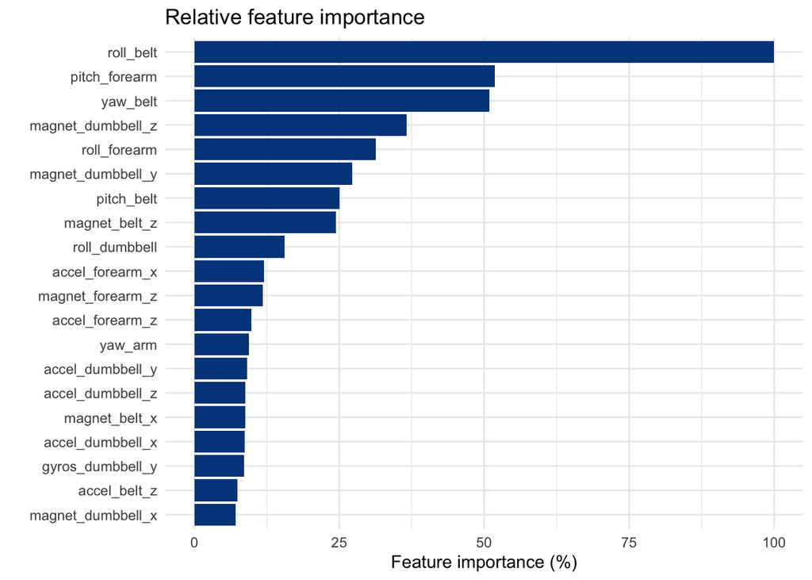

```r
imp <- varImp(fit)$importance
imp <- imp %>% arrange(-Overall) %>% slice(1:20) %>%
          mutate(name=fct_inorder(rownames(.)),
                 name=fct_rev(name))

ggplot(data=imp, aes(y=Overall, x=name)) +
  geom_bar(stat="identity", fill=pal_lancet()(1)) +
  coord_flip() +
  theme_minimal() +
  labs(x="", y="Feature importance (%)", title="Relative feature importance")
```

## Model testing

The trained model is used to predict movement classes in the test set. The predictions are presented in a table.

```r
rownames(test) <- test$X
test <- test %>% select(-X)
nearZero <- nearZeroVar(test, saveMetrics = TRUE)
train <- test %>% select_if(nearZero$percentUnique>1)

## predict
pred <- predict(fit, test)
table(number=c(1:20), pred)
```

```
##       pred
## number A B C D E
##     1  0 1 0 0 0
##     2  1 0 0 0 0
##     3  0 1 0 0 0
##     4  1 0 0 0 0
##     5  1 0 0 0 0
##     6  0 0 0 0 1
##     7  0 0 0 1 0
##     8  0 1 0 0 0
##     9  1 0 0 0 0
##     10 1 0 0 0 0
##     11 0 1 0 0 0
##     12 0 0 1 0 0
##     13 0 1 0 0 0
##     14 1 0 0 0 0
##     15 0 0 0 0 1
##     16 0 0 0 0 1
##     17 1 0 0 0 0
##     18 0 1 0 0 0
##     19 0 1 0 0 0
##     20 0 1 0 0 0
```